# TidyVerse CREATE: Exploring Selfie and ID Dataset

Randy Howk

2025-10-26

## Introduction

This vignette demonstrates the use of several **TidyVerse** packages to explore and analyze the ‘Selfie and ID 65,000+ Photos’ dataset from Kaggle. This dataset contains photos of individuals and their identification documents for facial recognition and KYC (Know Your Customer) tasks.

**Dataset Source:** [Kaggle - Selfie and ID Dataset](https://www.kaggle.com/datasets/simongraves/selfie-and-id-65000-photos)

### TidyVerse Packages Demonstrated

- **dplyr**: Data manipulation (filter, mutate, group_by, summarize, arrange)
- **ggplot2**: Data visualization
- **tidyr**: Data reshaping and tidying
- **stringr**: String manipulation
- **forcats**: Factor handling

## Loading Libraries and Data

```r
# Load TidyVerse packages
library(tidyverse)  # Loads dplyr, ggplot2, tidyr, readr, stringr, forcats, etc.
```

## Loading the Dataset

```r
# Load the dataset (NOTE: This CSV uses semicolons as delimiter!)
selfie_data_raw <- read_csv2("archive/Selie_ID.csv")  # read_csv2 handles semicolon-delimited files

# Clean column names (fix columns starting with numbers)
selfie_data <- selfie_data_raw %>%
  rename(
    id_photo_1_resolution = `1_id_photo_resolution`,
    id_photo_2_resolution = `2_id_photo_resolution`
  )

# Display first few rows
head(selfie_data)
```

```
## # A tibble: 6 × 38
##   set_id   age gender country ethnicity device_model age_printed_1 age_printed_2
##    <dbl> <dbl> <chr>  <chr>   <chr>     <chr>                <dbl>         <dbl>
## 1      1    45 FEMALE Ukraine European  Samsung M31             16            25
## 2      2    24 MALE   Pakist… Asian     Infinix not…            18            23
## 3      3    35 MALE   Egypt   Middle E… Infinix not…            33            34
## 4      4    19 FEMALE Nigeria African   Tecno Pop 7             18            18
## 5      5    31 FEMALE South … African   Samsung A05             25            17
## 6      6    25 MALE   Philip… Asian     Iphone 15 P…            22            21
## # ℹ 30 more variables: id_photo_1_resolution <chr>,
## #   id_photo_2_resolution <chr>, `1_selfie_photo_resolution` <chr>,
## #   `2_selfie_photo_resolution` <chr>, `3_selfie_photo_resolution` <chr>,
## #   `4_selfie_photo_resolution` <chr>, `5_selfie_photo_resolution` <chr>,
## #   `6_selfie_photo_resolution` <chr>, `7_selfie_photo_resolution` <chr>,
## #   `8_selfie_photo_resolution` <chr>, `9_selfie_photo_resolution` <chr>,
## #   `10_selfie_photo_resolution` <chr>, `11_selfie_photo_resolution` <chr>, …
```

```r
# Check structure and column names
glimpse(selfie_data)
```

```
## Rows: 10
## Columns: 38
## $ set_id                       <dbl> 1, 2, 3, 4, 5, 6, 7, 8, 9, 10
## $ age                          <dbl> 45, 24, 35, 19, 31, 25, 20, 25, 23, 32
## $ gender                       <chr> "FEMALE", "MALE", "MALE", "FEMALE", "FEMA…
## $ country                      <chr> "Ukraine", "Pakistan", "Egypt", "Nigeria"…
## $ ethnicity                    <chr> "European", "Asian", "Middle Eastern", "A…
## $ device_model                 <chr> "Samsung M31", "Infinix note11", "Infinix…
## $ age_printed_1                <dbl> 16, 18, 33, 18, 25, 22, 7, 20, 17, 30
## $ age_printed_2                <dbl> 25, 23, 34, 18, 17, 21, 6, 21, 19, 31
## $ id_photo_1_resolution        <chr> "962 x 1000", "1000 x 750", "1000 x 750",…
## $ id_photo_2_resolution        <chr> "907 x 1000", "1000 x 750", "1000 x 748",…
## $ `1_selfie_photo_resolution`  <chr> "1000 x 563", "1000 x 750", "1000 x 750",…
## $ `2_selfie_photo_resolution`  <chr> "1000 x 563", "1000 x 750", "1000 x 750",…
## $ `3_selfie_photo_resolution`  <chr> "1000 x 563", "1000 x 750", "1000 x 750",…
```

[output cut: 25 more lines]

## Data Exploration with dplyr

### 1. Basic Filtering and Selection

```r
# Filter for participants aged 25-35 from Asian ethnicity
young_asian <- selfie_data %>%
  filter(age >= 25 & age <= 35, ethnicity == 'Asian') %>%
  select(set_id, age, gender, country, device_model)

cat('Young Asian participants (25-35 years):\n')
```

```
## Young Asian participants (25-35 years):
```

```r
head(young_asian, 10)
```

```
## # A tibble: 1 × 5
##   set_id   age gender country     device_model
##    <dbl> <dbl> <chr>  <chr>       <chr>
## 1      6    25 MALE   Philippines Iphone 15 Pro Max
```

### 2. Creating New Variables with mutate()

```r
# Add calculated columns
selfie_enhanced <- selfie_data %>%
  mutate(
    # Calculate age verification accuracy
    age_diff_1 = abs(age - age_printed_1),
    age_diff_2 = abs(age - age_printed_2),

    # Categorize age groups
    age_group = case_when(
      age < 25 ~ '18-24',
      age < 35 ~ '25-34',
      age < 45 ~ '35-44',
      age < 55 ~ '45-54',
      TRUE ~ '55+'
    ),

    # Extract device brand using stringr
    device_brand = str_extract(device_model, '^[A-Za-z]+'),

    # Calculate average age discrepancy
    avg_age_diff = (age_diff_1 + age_diff_2) / 2
  )

head(selfie_enhanced %>% select(set_id, age, age_group, device_brand, avg_age_diff))
```

```
## # A tibble: 6 × 5
##   set_id   age age_group device_brand avg_age_diff
##    <dbl> <dbl> <chr>     <chr>               <dbl>
## 1      1    45 45-54     Samsung              24.5
## 2      2    24 18-24     Infinix               3.5
## 3      3    35 35-44     Infinix               1.5
## 4      4    19 18-24     Tecno                 1
## 5      5    31 25-34     Samsung              10
## 6      6    25 25-34     Iphone                3.5
```

### 3. Grouping and Summarizing Data

```r
# Analyze data by ethnicity and gender
demographic_summary <- selfie_enhanced %>%
  group_by(ethnicity, gender) %>%
  summarize(
    count = n(),
    avg_age = mean(age, na.rm = TRUE),
    avg_age_discrepancy = mean(avg_age_diff, na.rm = TRUE),
    min_age = min(age),
    max_age = max(age),
    .groups = 'drop'
  ) %>%
  arrange(desc(count))

print(demographic_summary)
```

```
## # A tibble: 6 × 7
##   ethnicity      gender count avg_age avg_age_discrepancy min_age max_age
##   <chr>          <chr>  <int>   <dbl>               <dbl>   <dbl>   <dbl>
## 1 Asian          MALE       3      23                6.83      20      25
## 2 African        FEMALE     2      25                5.5       19      31
## 3 European       FEMALE     2      34               14.8       23      45
## 4 African        MALE       1      25                4.5       25      25
## 5 Middle Eastern FEMALE     1      32                1.5       32      32
## 6 Middle Eastern MALE       1      35                1.5       35      35
```

### 4. Top Countries by Participant Count

```r
# Using count() and arrange() for ranking
top_countries <- selfie_data %>%
  count(country, name = 'participants') %>%
  arrange(desc(participants)) %>%
  head(10)

print(top_countries)
```

```
## # A tibble: 10 × 2
##    country        participants
##    <chr>                 <int>
##  1 Centro america            1
##  2 Egypt                     1
##  3 Kwnya                     1
##  4 Nigeria                   1
##  5 Pakistan                  1
##  6 Philippines               1
##  7 South Africa              1
##  8 Srilanka                  1
##  9 Turkey                    1
## 10 Ukraine                   1
```

## Data Visualization with ggplot2

### 1. Age Distribution by Gender

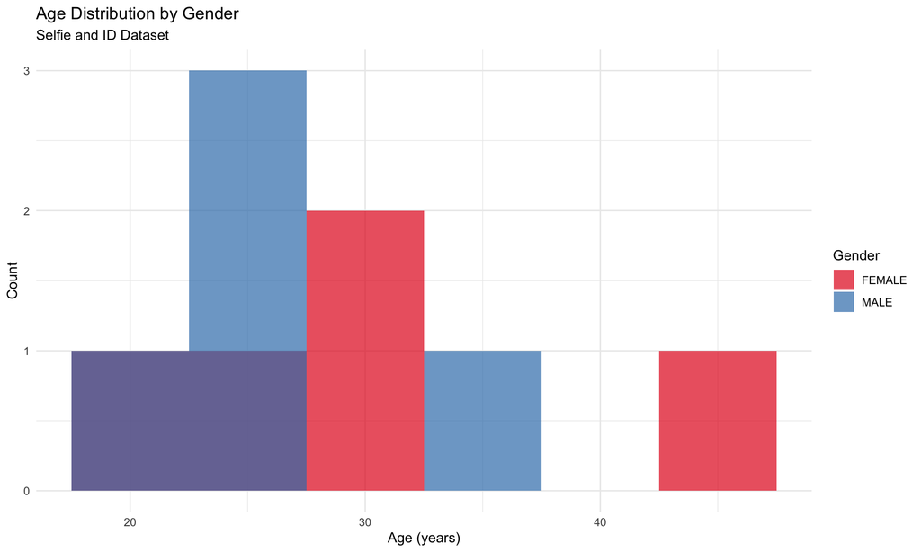

```r
ggplot(selfie_enhanced, aes(x = age, fill = gender)) +
  geom_histogram(binwidth = 5, alpha = 0.7, position = 'identity') +
  labs(
    title = 'Age Distribution by Gender',
    subtitle = 'Selfie and ID Dataset',
    x = 'Age (years)',
    y = 'Count',
    fill = 'Gender'
  ) +
  theme_minimal() +
  scale_fill_brewer(palette = 'Set1')
```

### 2. Ethnicity Distribution

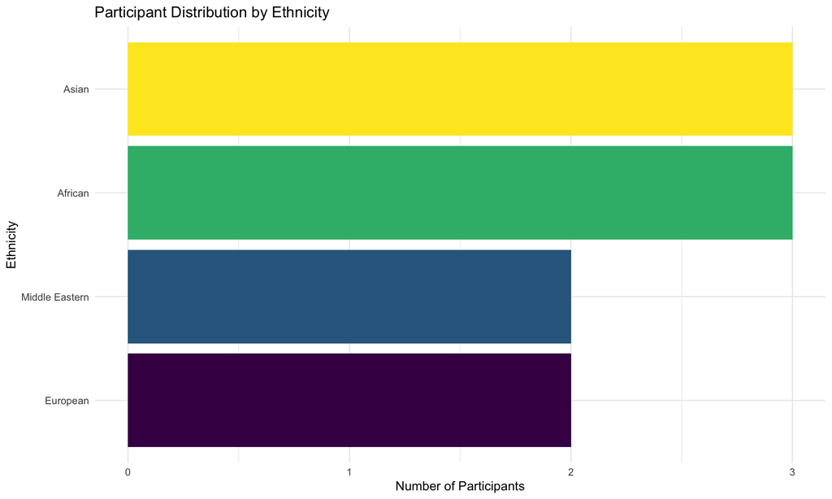

```r
ethnicity_counts <- selfie_data %>%
  count(ethnicity) %>%
  mutate(ethnicity = fct_reorder(ethnicity, n))

ggplot(ethnicity_counts, aes(x = ethnicity, y = n, fill = ethnicity)) +
  geom_col() +
  coord_flip() +
  labs(
    title = 'Participant Distribution by Ethnicity',
    x = 'Ethnicity',
    y = 'Number of Participants'
  ) +
  theme_minimal() +
  theme(legend.position = 'none') +
  scale_fill_viridis_d()
```

### 3. Age Verification Accuracy

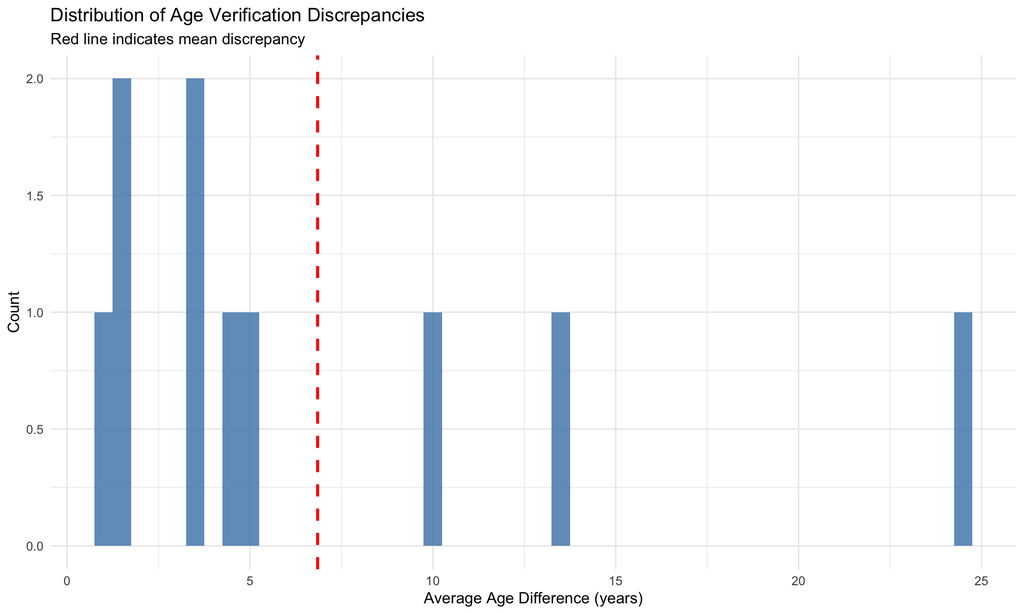

```r
ggplot(selfie_enhanced, aes(x = avg_age_diff)) +
  geom_histogram(binwidth = 0.5, fill = 'steelblue', alpha = 0.8) +
  geom_vline(aes(xintercept = mean(avg_age_diff)),
             color = 'red', linetype = 'dashed', size = 1) +
  labs(
    title = 'Distribution of Age Verification Discrepancies',
    subtitle = 'Red line indicates mean discrepancy',
    x = 'Average Age Difference (years)',
    y = 'Count'
  ) +
  theme_minimal()
```

### 4. Device Brand Usage by Gender

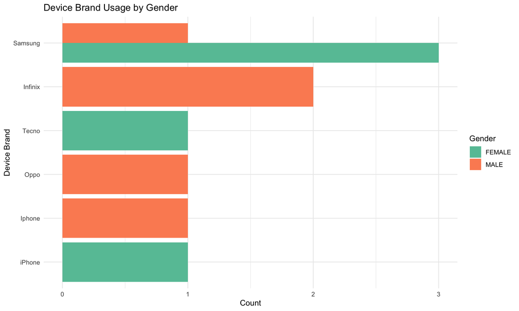

```r
device_gender <- selfie_enhanced %>%
  count(device_brand, gender) %>%
  filter(!is.na(device_brand))

ggplot(device_gender, aes(x = fct_reorder(device_brand, n), y = n, fill = gender)) +
  geom_col(position = 'dodge') +
  coord_flip() +
  labs(
    title = 'Device Brand Usage by Gender',
    x = 'Device Brand',
    y = 'Count',
    fill = 'Gender'
  ) +
  theme_minimal() +
  scale_fill_brewer(palette = 'Set2')
```

## Data Reshaping with tidyr

### Pivoting Data for Analysis

```r
# Reshape age data to compare printed ages
age_comparison <- selfie_data %>%
  select(set_id, age, age_printed_1, age_printed_2, ethnicity) %>%
  pivot_longer(
    cols = starts_with('age_printed'),
    names_to = 'document',
    values_to = 'printed_age'
  ) %>%
  mutate(
    document = str_replace(document, 'age_printed_', 'Document '),
    age_difference = abs(age - printed_age)
  )

head(age_comparison, 10)
```

```
## # A tibble: 10 × 6
##    set_id   age ethnicity      document   printed_age age_difference
##     <dbl> <dbl> <chr>          <chr>            <dbl>          <dbl>
##  1      1    45 European       Document 1          16             29
##  2      1    45 European       Document 2          25             20
##  3      2    24 Asian          Document 1          18              6
##  4      2    24 Asian          Document 2          23              1
##  5      3    35 Middle Eastern Document 1          33              2
##  6      3    35 Middle Eastern Document 2          34              1
##  7      4    19 African        Document 1          18              1
##  8      4    19 African        Document 2          18              1
##  9      5    31 African        Document 1          25              6
## 10      5    31 African        Document 2          17             14
```

### Visualizing Pivoted Data

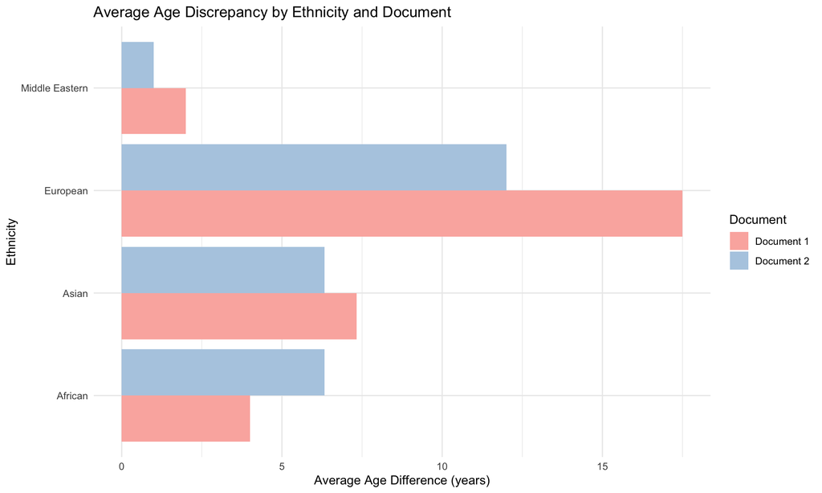

```r
age_diff_summary <- age_comparison %>%
  group_by(ethnicity, document) %>%
  summarize(avg_diff = mean(age_difference, na.rm = TRUE), .groups = 'drop')

ggplot(age_diff_summary, aes(x = ethnicity, y = avg_diff, fill = document)) +
  geom_col(position = 'dodge') +
  coord_flip() +
  labs(
    title = 'Average Age Discrepancy by Ethnicity and Document',
    x = 'Ethnicity',
    y = 'Average Age Difference (years)',
    fill = 'Document'
  ) +
  theme_minimal() +
  scale_fill_brewer(palette = 'Pastel1')
```

## Advanced Analysis: Combining Multiple TidyVerse Functions

### Complex Pipeline Example

```r
# Comprehensive analysis combining multiple operations
comprehensive_analysis <- selfie_enhanced %>%
  # Filter for quality data
  filter(!is.na(ethnicity), !is.na(device_brand)) %>%

  # Group by multiple variables
  group_by(age_group, ethnicity, gender) %>%

  # Calculate multiple statistics
  summarize(
    n_participants = n(),
    avg_age = round(mean(age), 1),
    avg_discrepancy = round(mean(avg_age_diff), 2),
    most_common_device = names(sort(table(device_brand), decreasing = TRUE))[1],
    .groups = 'drop'
  ) %>%

  # Filter for groups with sufficient sample size
  filter(n_participants >= 2) %>%

  # Arrange by multiple columns
  arrange(age_group, desc(n_participants))

print(comprehensive_analysis)
```

```
## # A tibble: 1 × 7
##   age_group ethnicity gender n_participants avg_age avg_discrepancy
##   <chr>     <chr>     <chr>           <int>   <dbl>           <dbl>
## 1 18-24     Asian     MALE                2      22             8.5
## # ℹ 1 more variable: most_common_device <chr>
```

### Faceted Visualization

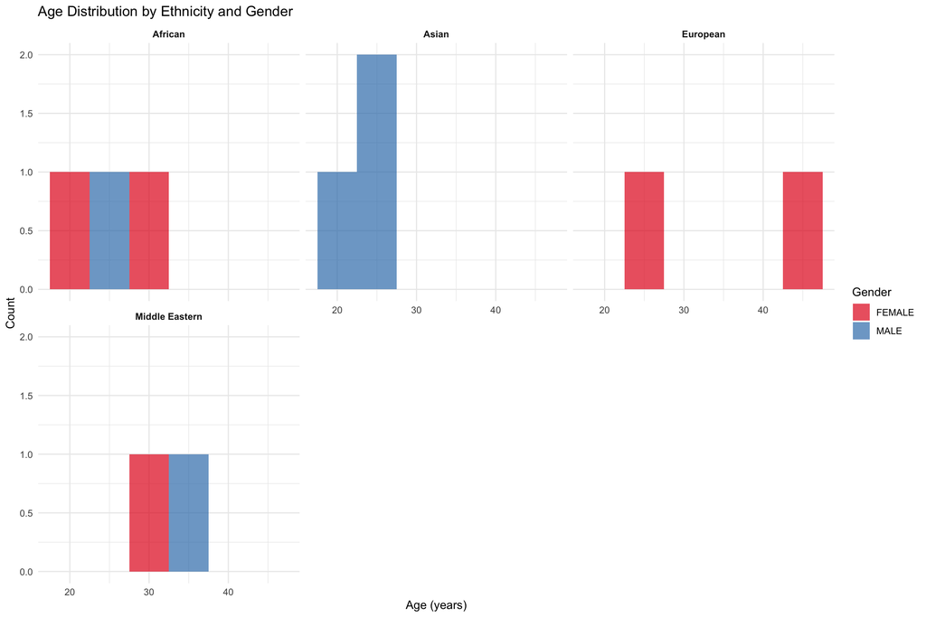

```r
ggplot(selfie_enhanced, aes(x = age, fill = gender)) +
  geom_histogram(binwidth = 5, alpha = 0.7) +
  facet_wrap(~ethnicity, ncol = 3) +
  labs(
    title = 'Age Distribution by Ethnicity and Gender',
    x = 'Age (years)',
    y = 'Count',
    fill = 'Gender'
  ) +
  theme_minimal() +
  theme(strip.text = element_text(face = 'bold')) +
  scale_fill_brewer(palette = 'Set1')
```

## Key Insights

### Summary Statistics

```r
# Overall summary
summary_stats <- selfie_enhanced %>%
  summarize(
    total_participants = n(),
    avg_age = round(mean(age), 1),
    age_range = paste(min(age), '-', max(age)),
    unique_countries = n_distinct(country),
    unique_devices = n_distinct(device_brand),
    avg_verification_error = round(mean(avg_age_diff), 2)
  )

cat('Dataset Summary:\n')
```

```
## Dataset Summary:
```

```r
print(summary_stats)
```

```
## # A tibble: 1 × 6
##   total_participants avg_age age_range unique_countries unique_devices
##                <int>   <dbl> <chr>                <int>          <int>
## 1                 10    27.9 19 - 45                 10              6
## # ℹ 1 more variable: avg_verification_error <dbl>
```

## Conclusion

This vignette demonstrated several key **TidyVerse** capabilities:

1. **dplyr**: Filtering, selecting, mutating, grouping, and summarizing data
2. **ggplot2**: Creating various visualizations (histograms, bar charts, faceted plots)
3. **tidyr**: Reshaping data with pivot_longer for comparative analysis
4. **stringr**: Extracting and manipulating string data
5. **forcats**: Reordering factors for better visualizations

### TidyVerse Functions Used:

- `filter()` - Subset rows based on conditions
- `select()` - Choose specific columns
- `mutate()` - Create new variables
- `group_by()` - Group data for aggregation
- `summarize()` - Calculate summary statistics
- `arrange()` - Sort data
- `count()` - Count observations
- `pivot_longer()` - Reshape data from wide to long format
- `ggplot()` - Create visualizations
- `str_extract()` - Extract patterns from strings
- `fct_reorder()` - Reorder factors by another variable

## References

- Dataset: [Selfie and ID 65,000+ photos on Kaggle](https://www.kaggle.com/datasets/simongraves/selfie-and-id-65000-photos)
- TidyVerse: https://www.tidyverse.org/
- R for Data Science: https://r4ds.had.co.nz/